# Classroom Notes, Week 2 - Exploratory Data Analysis

Reginald Carey

March 6, 2015

Lattice Plotting System

xyplot

bwplot

histogram

stripplot

dotplot

splom

levelplot, contourplot

Lattice functions generally take a function as the first parameter

```
xyplot(y ~ x | f * g, data)
```

on the left of the ~ is the y-axis, on the right is the x-axis

f and g are optional conditioning variables, the * indicates an interaction bewteen two variables.

data is a frame or list. If no data frame is passed, then the parent frame is used.

# Simple Lattice Plot

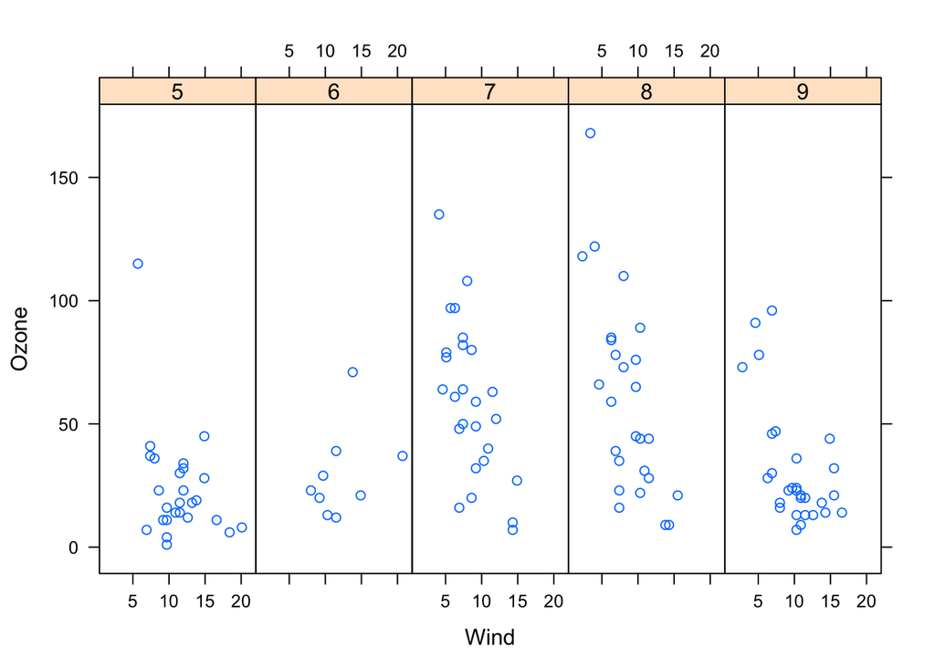

```r
library(datasets)
library(lattice)
## Convert 'month' to a factor variable
airquality <- transform(airquality, Month = factor(Month))
xyplot(Ozone ~ Wind | Month, data = airquality, layout = c(5, 1))
```

Lattice produces objects of type *trellis*

autoprinting takes care of printing a *trellis* object (creates the graph)

# Lattice Behaviour

```r
p <- xyplot(Ozone ~ Wind, data = airquality) ## Nothing happens here!
```

Now we try to print it:

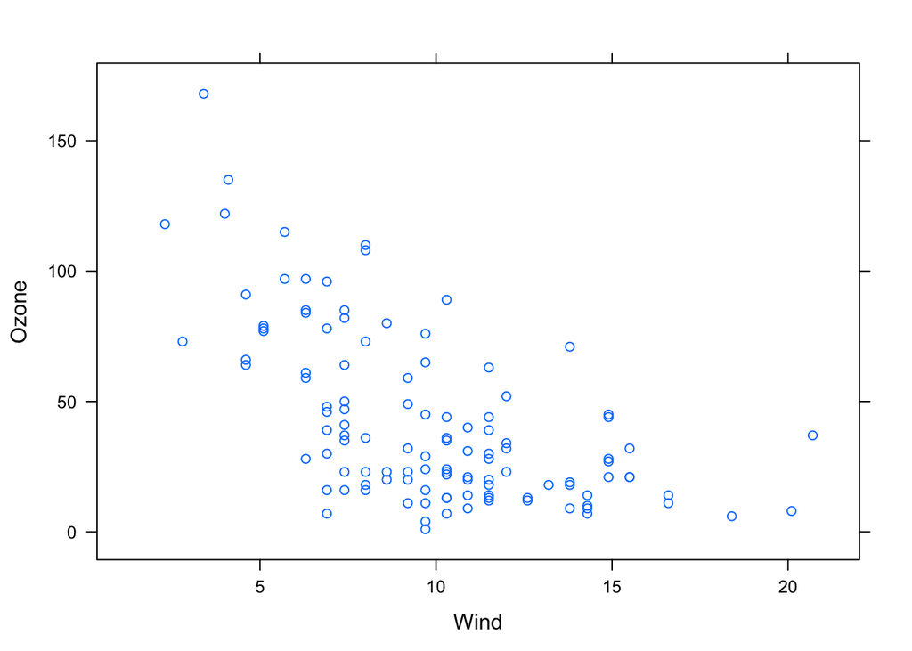

```r
print(p) ## Plot appears
```

Auto printing:

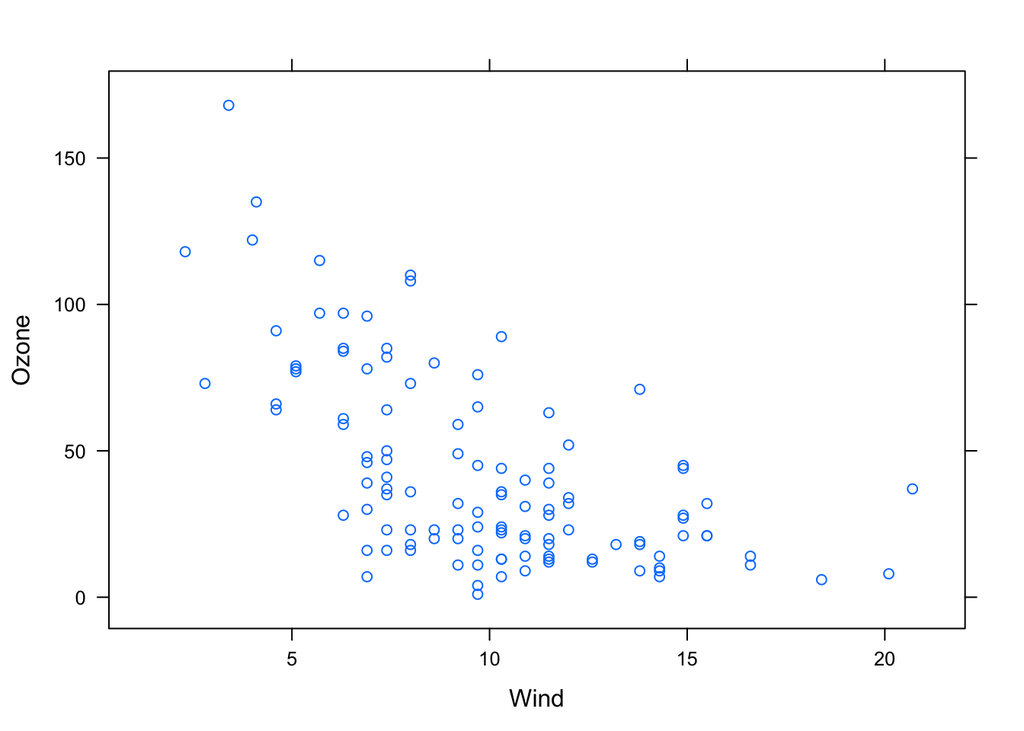

```r
xyplot(Ozone ~ Wind, data = airquality) ## Auto-printing
```

# Lattice Panel Functions

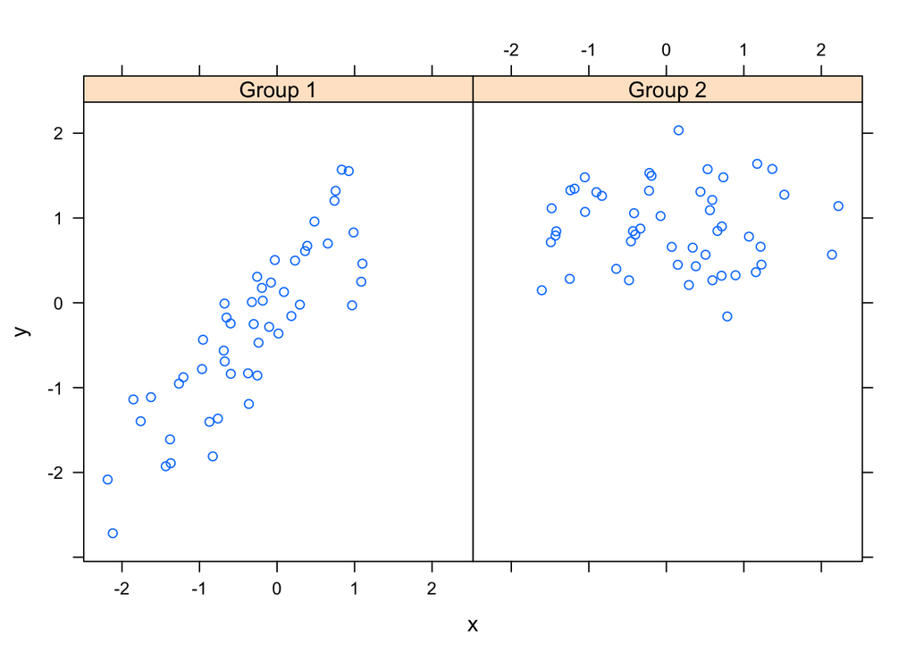

```r
set.seed(10)
x <- rnorm(100)
f <- rep(0:1, each = 50)
y <- x + f - f * x  + rnorm(100, sd = 0.5)
f <- factor(f, labels = c("Group 1", "Group 2"))
xyplot(y ~ x | f, layout = c(2,1))  ## Plot with 2 panels
```

Custom Panel Function

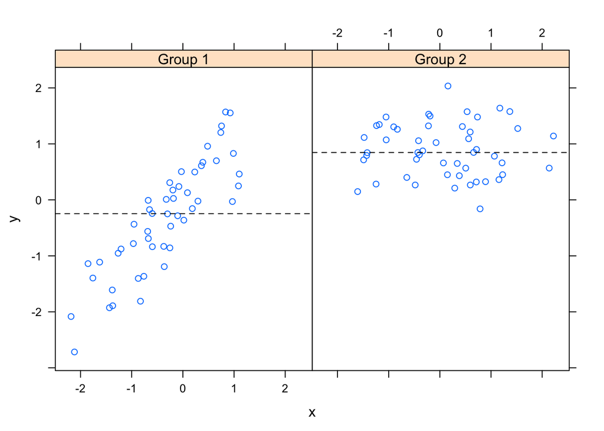

```r
xyplot(y ~ x | f, panel = function(x,y,...) {
  panel.xyplot(x,y,...) ## first call default panel function for 'xyplot'
  panel.abline(h = median(y), lty = 2) ## add a horizontal dashed line at the median
})
```

Regression Line

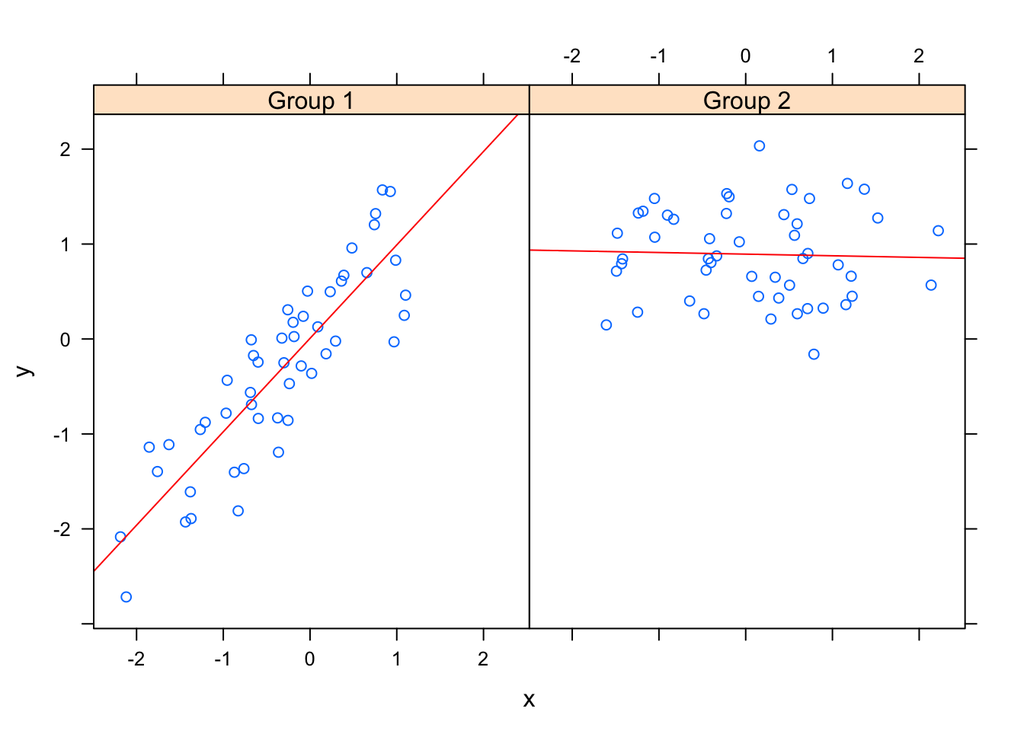

```r
xyplot(y ~ x | f, panel = function(x, y, ...) {
  panel.xyplot(x, y, ...) ## first call default panel function for 'xyplot'
  panel.lmline(x, y, col = 2) ## add a horizontal dashed line at the median
})
```

# GGPLOT2 - part 1

Grammar of Graphics

Documentation at http://ggplot2.org

## The Basics: qplot()

- Works similar to plot function in base graphics system.
- Looks for data in a data frame, similar to lattice, or in the parent environment.
- plots are made up of aesthetics (size, shape, color) and geoms (points, lines)
- Factors are important because they indicate subsets of the data.
- The qplot() hides what goes on underneath.
- ggplot() is the core function and very flexible for doing things qplot() cannot do.

# GGPLOT - part 2

```r
library(ggplot2)
str(mpg)
```

```
## 'data.frame':    234 obs. of  11 variables:
##  $ manufacturer: Factor w/ 15 levels "audi","chevrolet",..: 1 1 1 1 1 1 1 1 1 1 ...
##  $ model       : Factor w/ 38 levels "4runner 4wd",..: 2 2 2 2 2 2 2 3 3 3 ...
##  $ displ       : num  1.8 1.8 2 2 2.8 2.8 3.1 1.8 1.8 2 ...
##  $ year        : int  1999 1999 2008 2008 1999 1999 2008 1999 1999 2008 ...
##  $ cyl         : int  4 4 4 4 6 6 6 4 4 4 ...
##  $ trans       : Factor w/ 10 levels "auto(av)","auto(l3)",..: 4 9 10 1 4 9 1 9 4 10 ...
##  $ drv         : Factor w/ 3 levels "4","f","r": 2 2 2 2 2 2 2 1 1 1 ...
##  $ cty         : int  18 21 20 21 16 18 18 18 16 20 ...
##  $ hwy         : int  29 29 31 30 26 26 27 26 25 28 ...
##  $ fl          : Factor w/ 5 levels "c","d","e","p",..: 4 4 4 4 4 4 4 4 4 4 ...
##  $ class       : Factor w/ 7 levels "2seater","compact",..: 2 2 2 2 2 2 2 2 2 2 ...
```

### ggplot2 “Hello, world!”

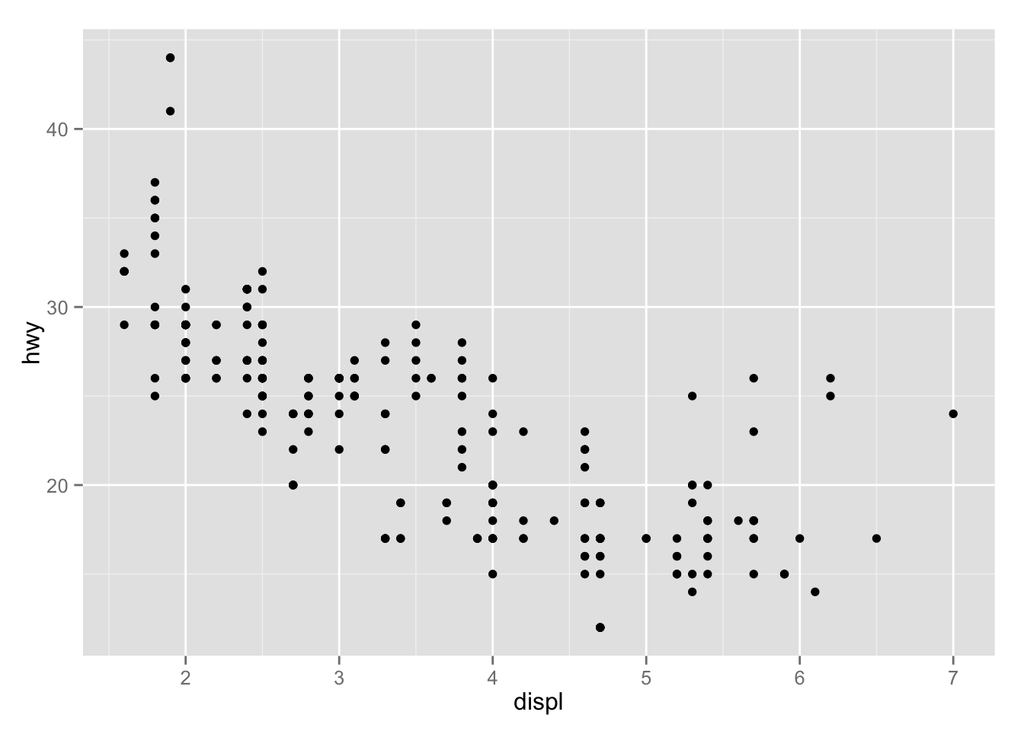

```r
library(ggplot2)
qplot(displ, hwy, data = mpg)
```

### Modifying the aesthetics

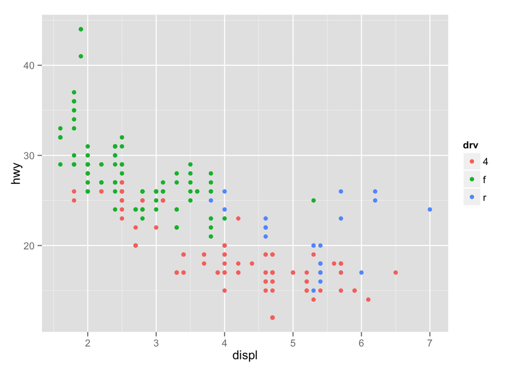

```r
library(ggplot2)
qplot(displ, hwy, data = mpg, color = drv)
```

### Adding a geom - loess line

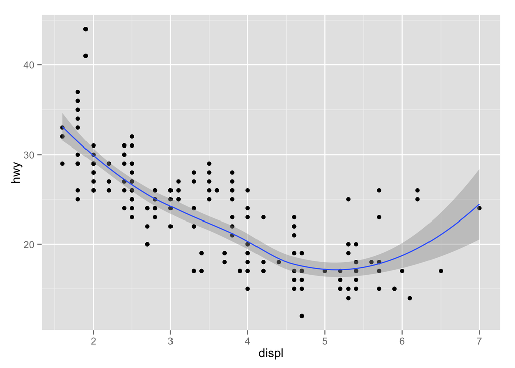

```r
library(ggplot2)
qplot(displ, hwy, data = mpg, geom=c("point", "smooth"), method="loess")
```

### Histograms

```
## stat_bin: binwidth defaulted to range/30. Use 'binwidth = x' to adjust this.
```

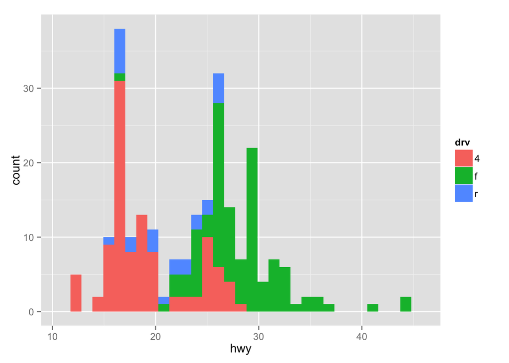

```r
library(ggplot2)
qplot(hwy, data = mpg, fill = drv)
```

### Facets

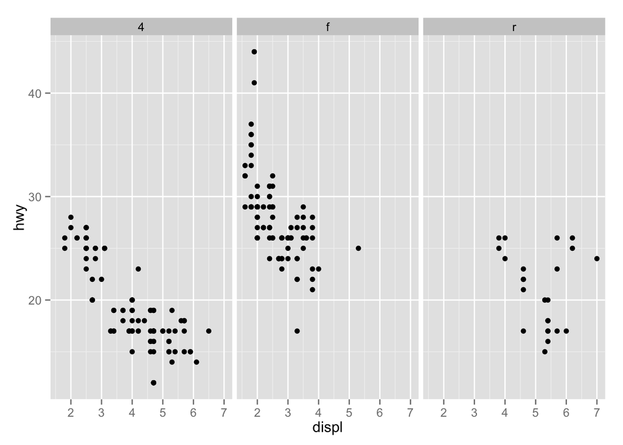

```r
library(ggplot2)
qplot(displ, hwy, data = mpg, facets = . ~ drv)
```

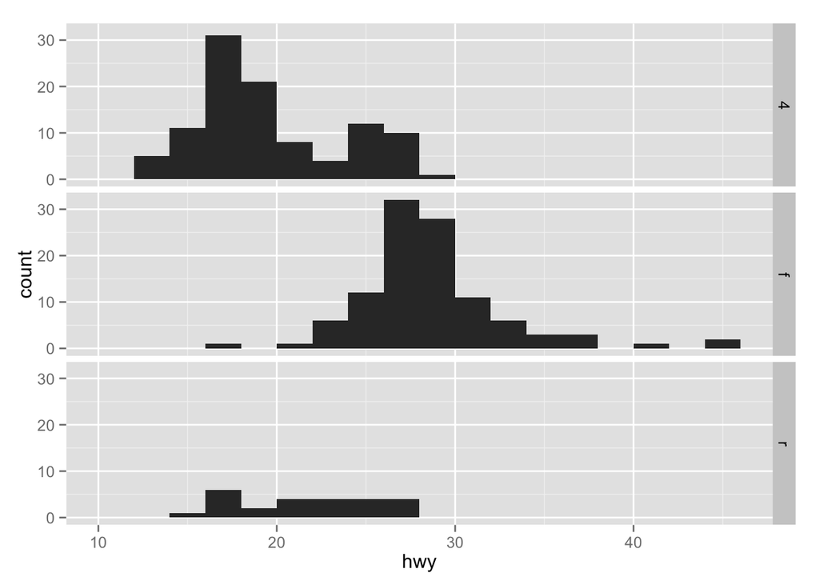

```r
library(ggplot2)
qplot(hwy, data = mpg, facets = drv ~ ., binwidth = 2)
```

# The ggplot2 Plotting System - Part 2

An implementation of the *Grammar of Graphics* by Leland Wilkinson

## Basic components

- A **data frame**
- **aesthetic mappings**: how data are mapped to color, size, etc.
- **geoms**: geometric objects like points, likes, shapes.
- **facets**: for conditional plots.
- **stats**: statistical transformations like binning, quantiles, smoothing.
- **scales**: what scale an aesthetic map users (example: male = red, female = blue).
- **coordinate system**

## Building Plots with ggplot2

- When building plots in ggplot2, the “artist’s palette” model may be the closest analogy
- Plots are built up in layers
  - plot the data
  - overlay a summary
  - metadata and annotation

# Quiz # 2

## Question 7

```r
library(datasets)
data(airquality)
```

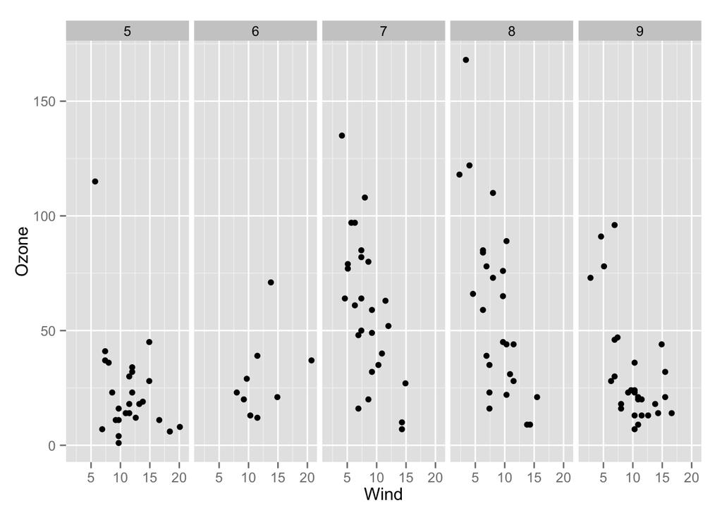

```r
airquality = transform(airquality, Month = factor(Month))
qplot(Wind, Ozone, data = airquality, facets = . ~ Month)
```